# 05 Tamaño de la Muestra.

2024-02-06

## Tema 1.4 Tamaño de la Muestra.

## Tema 1.4.1 Introducción.

- En los temas [1-3] hemos estudiado técnicas para la estimación de parámetros.
- En los temas [1-3] técnicas para el cómputo de probabilidades.
- Pero es necesario determinar un tamaño de muestra adecuado para estimar con precisión nuestros parámetros.

## Tema 1.4.2 Tipo de variable.

¿Qué tipo de variable vamos a muestrear?

- **Variables Continuas**: Se miden (Tiempo, temperatura, velocidad…)
- **Variables Discretas**: Se cuentan (# hijos, # estudiantes, # maestros..)

## Tema 1.4.3 Tipo de estudio.

- **Estudios de observación**: implican observar y medir individuos o grupos sin intervenir ni manipular variables. En los estudios observacionales, los investigadores simplemente observan lo que sucede naturalmente.
- **Estudios experimentales** implican la manipulación activa de variables y la evaluación de los efectos de esas manipulaciones. Los investigadores controlan y manipulan variables para establecer relaciones de causa y efecto.

## Tema 1.4.3. Tipo de estudio, Observación.

Determinantes del rendimiento académico:

- Se recopila datos sobre horas de estudio.
- Asistencia a clases.
- Uso de recursos de aprendizaje.
- Evaluaciones del profesor.

Sin intervenir en los hábitos de estudio de los estudiantes.

## Tema 1.4.3. Tipo de estudio, Experimental.

Determinantes del rendimiento académico:

- Se asignan aleatoriamente a dos grupos de estudiantes.
- Se controlan las variables y la influencia externa.
- Un grupo usa una técnica de estudio específica(novedosa)
- Otro grupo sigue sus métodos habituales.
- Se mide y compara el rendimiento de ambos grupos.

## Tema 1.4.3. Tipo de estudio, Observación.

Los estudios de observación:

- Son más comunes en las ciencias sociales.
- Tienden a tener más problemas de sesgo (selección, medición.
- Es más complicado establecer relaciones causa-efecto.
- Hay más abundancia de datos.

## Tema 1.4.3. Tipo de estudio, Experimental.

Los estudios experimentales (RCT):

- Tienden a tener más menos problemas de sesgo.
- Es más fácil establecer relaciones causa-efecto.
- Es más costoso recopilar datos.
- Pueden tener problemas éticos.
- No aplica para todas las variables.

## Tema 1.4.3. Abundancia de Estudios de Observación.

- Relevancia y aplicabilidad en la vida práctica.
- Abundancia de datos.
- Menos costo y problemas éticos.
- Menos complejos.

## Tema 1.4.4. Muestreo con Reemplazo

- En el muestreo con reemplazo, cada elemento de la población tiene la misma probabilidad de ser seleccionado en cada extracción.
- Después de seleccionar un elemento, este se devuelve a la población antes de realizar la siguiente extracción.
- Este método permite que un elemento sea seleccionado más de una vez en la muestra.

## Tema 1.4.4. Muestreo sin Reemplazo

- En el muestreo sin reemplazo, cada elemento de la población tiene la misma probabilidad de ser seleccionado en la primera extracción.
- Este método garantiza que cada elemento sea seleccionado exactamente una vez en la muestra.

## Tema 1.4.4. Muestreo con Reemplazo (situaciones)

- \(N<n\)
- En situaciones donde la reposición de los elementos no afecta significativamente los resultados.
- Para alcanzar mejores propiedades cuando la población es pequeña.

## Tema 1.4.4. Muestreo sin Reemplazo (situaciones)

- \(N>n\)
- Garantizar que cada elemento sea seleccionado exactamente una vez en la muestra.
- La reposición de los elementos podría distorsionar los resultados.
- \(N/n\): Depende de cada estudio, requiere investigación.

## Tema 1.4.5. Condiciones Principales del Muestreo iid

El muestreo iid (independiente e idénticamente distribuido) es fundamental para aplicar correctamente la fórmula de tamaño de muestra. Las principales condiciones son:

1. **Independencia**: Las observaciones en la muestra deben ser independientes entre sí, es decir, el valor de una observación no está influenciado por el valor de otra.
2. **Identidad de Distribución**: Las observaciones deben tener la misma distribución de probabilidad.
3. **Tamaño de Muestra Suficiente**: El tamaño de la muestra debe ser lo suficientemente grande para garantizar que las estimaciones sean precisas y confiables.

## La Distribución de la Media Muestral

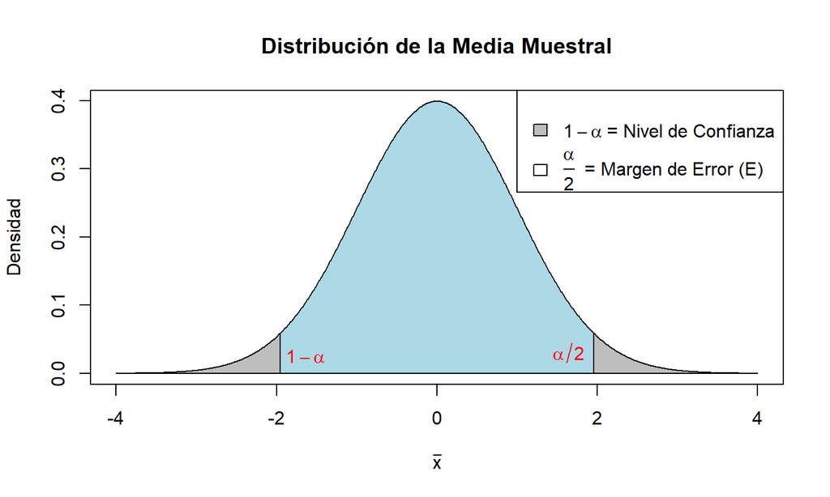

## Tema 1.4.5 Estimación de un \(n\): Continua o Discreta.

Fórmula:

\[ n = \frac{{Z^2 \cdot \sigma^2}}{{E^2}} \]

Donde: - \(n\) es el tamaño de la muestra. - \(Z\) es el valor crítico de la distribución normal estándar, asociado con el nivel de confianza deseado. - \(\sigma\) es la desviación estándar de la población o su estimador. - \(E\) es el margen de error deseado (nivel de significancia \(\alpha\)). - Con o sin remplazo.

## Tema 1.4.5 Estimación de un \(n\): Continua o Discreta, Ejemplo (1/1).

- Se quiere estimar la estatura media de los estudiantes de una universidad.
- Con un nivel de confianza del 90%.
- Supongamos también que la desviación estándar es de 8 centímetros.

## Tema 1.4.5 Estimación de un \(n\): Continua o Discreta, Ejemplo (1/2).

Si el nivel de confianza del 90%, el

\[ E = \alpha = 1-.9 =.1 \]

Se busca en la tabla el valor crítico para 90%

\[ n = \frac{{(1.2815)^2 \cdot (8)^2}}{{(.1)^2}} \] Donde: \[ n = 10511.2 \sim 10512 \]

## Tema 1.4.5 Estimación de un \(n\): Continua o Discreta, Ejemplo (2/1)

Para estudiar la imagen de los diferentes políticos, se pide a los encuestados que los evalúen en una escala (continúa) de 0 a 10 puntos. - Si la desviación típica de esta variable es de 1.5 puntos

¿Cuántos casos se necesitan para alcanzar un error máximo de 0.05 puntos?

## Tema 1.4.5 Estimación de un \(n\): Continua o Discreta, Ejemplo (2/2)

- \(E\) es el error máximo deseado, que es de 0.05 puntos.
- El nivel de confianza \(1 - \alpha=0.95\) Entonces:

\[ n = \frac{{1.96^2 \cdot 1.5^2}}{{0.05^2}} \]

## Tema 1.4.5 Estimación de un \(n\): Para Proporción

- Cuando la proporción de una variable categórica (\(X\)) es conocida:

\[ n = \frac{{Z^2 \cdot p \cdot (1-p)}}{{E^2}} \]

Donde: - \(n\) es el Tamaño de muestra necesario.

- \(p\) es la proporción estimada (constante).
- \(Z\) es el valor crítico de la distribución normal.
- \(E\) es el margen de error deseado.
- \(X\) es binomial (éxito o fracaso).
- Con o sin remplazo.

## Tema 1.4.5 Estimación de un \(n\): Para Proporción Ejemplo (1/1)

- Se quiere estimar la proporción de hogares que poseen automóvil en una determinada ciudad.
- Si se estima que la proporción estimada de hogares con automóvil es del 60%. ¿Cuál es el tamaño de muestra necesario para estimar esta proporción con un margen de error máximo del 5% y un nivel de confianza del 95%.

## Tema 1.4.5 Estimación de un \(n\): Para Proporción Ejemplo (1/2)

Substituyendo:

\[ n = \frac{{1.96^2 \cdot 0.6 \cdot (1-0.6)}}{{0.05^2}} \]

La muestra:

\[ n = 260 \]

```
## [1] 259.7322
```

## Tema 1.4.5 Estimación de un \(n\): Para Proporción Ejemplo (2/1)

- Se quiere estimar la proporción de personas que tienen una cuenta bancaria
- Si se estima que la proporción estimada de personas con cuenta bancaria es del 40%. ¿Cuál es el tamaño de muestra necesario para estimar esta proporción con un nivel de confianza del 90%?

## Tema 1.4.5 Estimación de un \(n\): Para Proporción Ejemplo (2/2)

Substituyendo:

\[ n = \frac{{1.2815^2 \cdot 0.4 \cdot (1-0.4)}}{{0.1^2}} \]

La muestra:

\[ n = 40 \]

```
## [1] 1.281552
```

```
## [1] 39.41699
```

## Tema 1.4.5 Estimación de un \(n\): Proporcion Sin \(\sigma\)

Usando la fórmula: \[ n = \left(\frac{Z}{2E}\right)^2 \]

- \(Max(\sigma) = \sqrt{n \cdot p \cdot (1-p)}=0.5\)
- Suele dar un tamaño de muestra mayor.

## Tema 1.4.5 Estimación de un \(n\): Proporción Sin \(\sigma\) Ejemplo (1/1)

- Estimar el porcentaje de estudiantes universitarios que tienen una tablet con un margen de error máximo de 10% ¿Cuántos estudiantes se necesitan para esta muestra?

## Tema 1.4.5 Estimación de un \(n\): Proporcion Sin \(\sigma\) Ejemplo (2/1)

- Se quiere estimar el porcentaje de hogares que tienen acceso a internet con un margen de error máximo de 5% ¿Cuántos hogares se necesitan para esta muestra?

Calculamos el tamaño de muestra: \[ n = \left(\frac{1.6448}{2 \times 0.05}\right)^2 \] \[ n = 271 \]

## Tema 1.4.5 Estimación de un \(n\): con \(N\)

- Si se conoce el tamaño de la población.
- Si se muestrea sin remplazo. Entonces, se usa:

\[ n = \frac{N}{1+N(e)^2} \]

## Tema 1.4.5 Estimación de un \(n\): con \(N\) Ejemplo (1/1)

Se quiere estimar la proporción de personas que consumen pasta en una ciudad con una población de 500.000 habitantes, con un nivel de precisión del 5% y un nivel de confianza del 95%.

## Tema 1.4.5 Estimación de un \(n\): con \(N\) Ejemplo (1/2)

\[ n = \frac{500000}{1+500000(0.05)^2} \] \[ n = 400 \]

```
## [1] 399.6803
```

```
## [1] 400
```

## Revisión

## Revisión

```
## Versión: 07/02/2024
```

## Bibliografía

## Bibliografía

- Smith, G. (2015). *Essential statistics, regression, and econometrics.*
- Stock, J. H., & Watson, M. W. (2020). Introduction to econometrics. Pearson.
- Hernández-Sampieri, R., Fernández-Collado, C., & Baptista-Lucio, P. (2014). Metodología de la investigación (6a ed.). McGraw-Hill.
- [Cochran’s sample size formula p variable meaning and intuition](https://stats.stackexchange.com/questions/443708/cochrans-sample-size-formula-p-variable-meaning-and-intuition)